# Polyploid Linkage Mapping

Fabian Grandke

2016-07-14

# Introduction

This Vignette shows an example usecase for generating a linkage map for polyploid data in R.

# Installation

First, we need to install the package `pergola`. Second, we set a seed to ensure that this vignette is reproducable.

```r
library(pergola)
```

```r
set.seed(31415)
```

Next, we load the example dataset from the package.

```r
data("simTetra")
```

```r
simTetra[1:5, 1:12]
```

```
##      F2_001_1 F2_001_2 F2_001_3 F2_001_4 F2_002_1 F2_002_2 F2_002_3
## A001        0        1        0        0        1        0        0
## A002        0        1        0        0        1        0        0
## A003        0        1        0        0        1        0        0
## A004        0        1        0        0        0        0        0
## A005        0        1        0        0        0        0        0
##      F2_002_4 F2_003_1 F2_003_2 F2_003_3 F2_003_4
## A001        1        1        1        0        1
## A002        1        1        0        0        1
## A003        1        1        0        0        1
## A004        1        1        0        0        1
## A005        1        1        0        0        1
```

# Data manipulation

As the data is simulated, the markers are grouped according to their chromosomes and ordered according to linkage. Our goal is to predict these. Thus, we want to randomize the order of the markers. The dataset contains the order of the alleles within the samples (haplotypes). This should also be randomized, because it provides information about the exact number of recombinations, which is approximated later.

```r
simTetraGen <- shuffleInput(simTetra, ploidy = 4)
simTetraGen[1:5, 1:12]
```

```
##      F2_001_1 F2_001_2 F2_001_3 F2_001_4 F2_002_1 F2_002_2 F2_002_3
## G010        1        0        1        1        1        1        1
## C007        1        0        0        0        0        0        0
## B003        1        0        1        0        1        1        0
## D009        1        0        0        0        0        0        1
## A008        1        0        0        0        0        1        1
##      F2_002_4 F2_003_1 F2_003_2 F2_003_3 F2_003_4
## G010        0        0        1        0        0
## C007        1        1        1        1        1
## B003        0        0        0        0        1
## D009        0        1        1        0        0
## A008        0        1        0        1        0
```

Now that the data is randomized, we can treat it like real data. In the next step we collapse four columns into one. That way we have one column per sample without loosing information.

```r
simTetraGen <- basesToGenotypes(simTetraGen, ploidy = 4)
simTetraGen[1:5, 1:6]
```

```
##      [,1] [,2] [,3] [,4] [,5] [,6]
## G010    3    3    1    1    2    1
## C007    1    1    4    3    2    2
## B003    2    2    1    1    1    1
## D009    1    1    2    2    2    1
## A008    1    2    2    2    2    1
```

Finally, the data is ready to be analyzed.

# Analysis

## Calculate pairwise recombination frequencies

Now, we want to compare all markers with each other. This allows us to group similar markers together and define linkage groups. The first step is the calculation of pairwise recombination frequencies. Unlike other tools we do not use the expectation–maximization (EM) algorithm or maximum-likelihood (ML) methods. Instead, we approximate the recombination events and always expect the minimum number.

```r
rf <- calcRec(simTetraGen, ploidy = 4)
```

`rf` is the matrix containing the recombination frequencies for all pairs of markers.

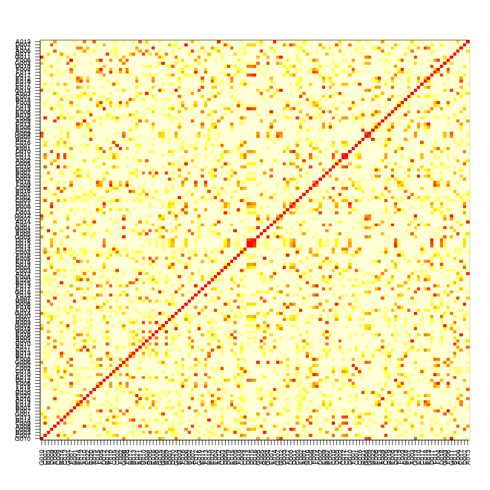

```r
image(rf, xaxt = 'n', yaxt = 'n')
axis(side = 1, at = seq(0, 1, length.out = nrow(rf)),
     labels = rownames(rf), las = 2, cex.axis = 0.8)
axis(side = 2, at = seq(0, 1, length.out = nrow(rf)),
     labels = rownames(rf), las = 2, cex.axis = 0.8)
```

The colors represent the different frequencies (yellow = high, red = low). We do not see any structure in the data set, except the diagonal. It is red because each there is no recombination between a marker and itself.

## Linkage grouping

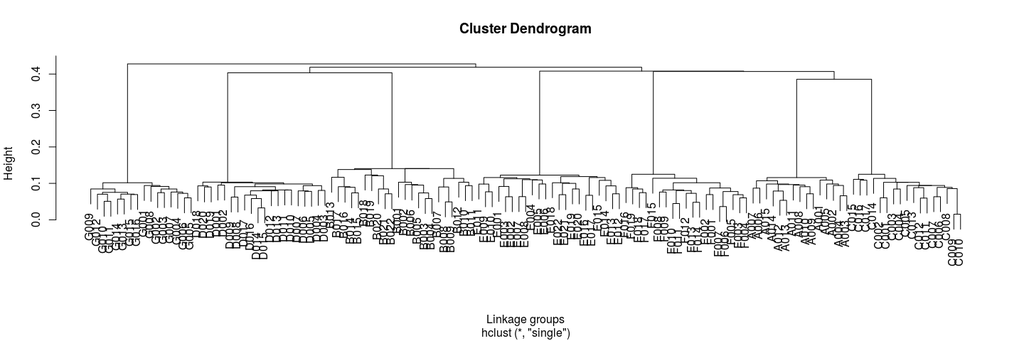

```r
plotRf(rf)
```

The plot shows seven easily distinguishable clusters, as expected. The other implemented visualization is an image of the recombination frequency values:

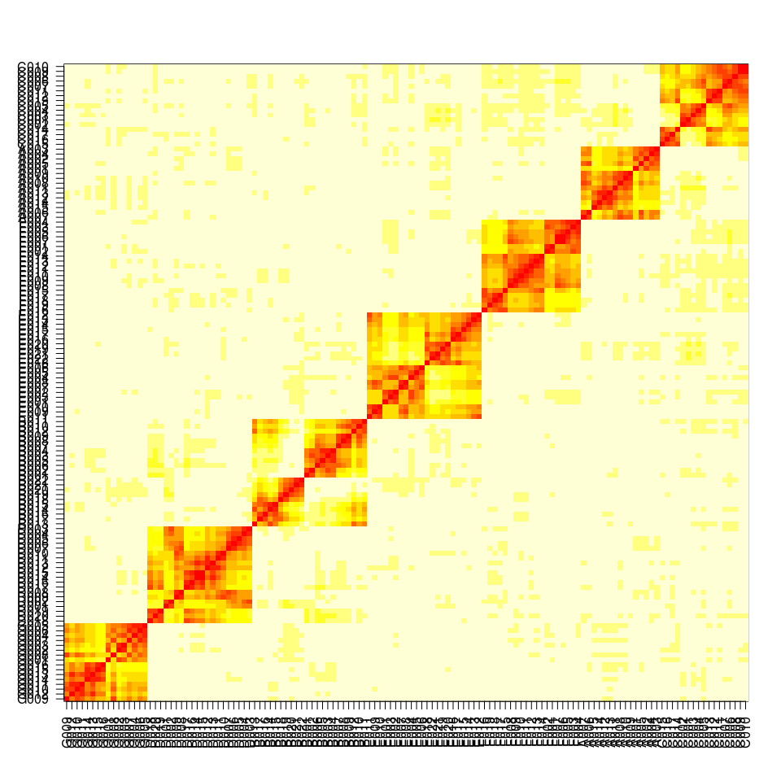

```r
plotRf(rf, plottype = "image")
```

Here we see seven rectangles and assume seven linkage groups. Hence, we split the data with `splitChr`.

```r
split <- splitChr(rf, nchr = 7)
table(split$split)
```

```
##
##  1  2  3  4  5  6  7
## 16 17 22 20 15 19 22
```

```r
head(split)
```

```
##      names split dup
## G010  G010     1   0
## C007  C007     2   0
## B003  B003     3   0
## D009  D009     4   0
## A008  A008     5   0
## C009  C009     2   0
```

`table()` shows us how many markers are on each chromosome.

### Additional parameters

In case that single markers end up in own linkage groups, one might want to filter them out with the parameter `filter = TRUE`. If many markers are highly similar, removing those duplicates is adviced. They have no added value for the linkage map and end up at the same position.

## Marker ordering

Now, that we grouped our markers, we want to find the correct order of markers within the linkage groups. Filtered markers (chromosome 0) would be ignored.

```r
split <- sortLeafs(rf, split)
head(split)
```

[output not shown]

`split$order` is the global order of markers. We can visualize it with `image()`.

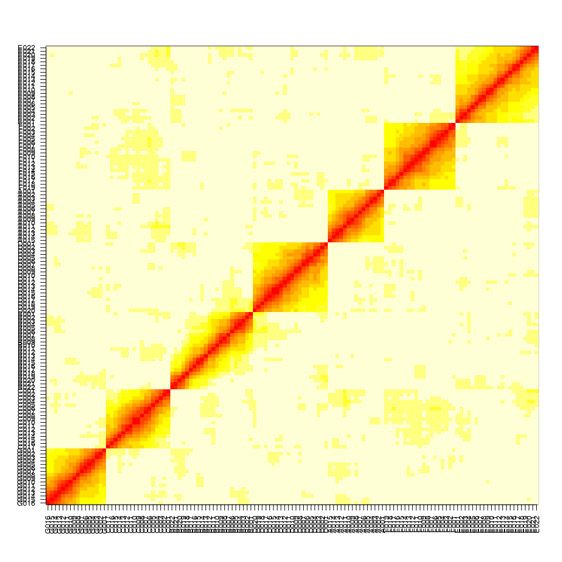

```r
image(rf[split$order, split$order], xaxt = 'n', yaxt = 'n')
axis(side = 1, at = seq(0, 1, length.out = nrow(rf)),
     labels = rownames(rf)[split$order], las = 2, cex.axis = 0.8)
axis(side = 2, at = seq(0, 1, length.out = nrow(rf)),
     labels = rownames(rf)[split$order], las = 2, cex.axis = 0.8)
```

We see that the order within the chromosomes has improved because the red values moved closer to the diagonal.

### Example of ambiguous orders

Here we show an example where two orders are equally good when only one neighbor is included.

```r
set.seed(3)
ambRF <- cbind(c(0, 2, 4, 6, 8, 12),
               c(2, 0, 4, 4, 7, 10),
               c(4, 4, 0, 2, 4, 7),
               c(6, 4, 2, 0, 4, 5),
               c(8, 7, 4, 4, 0, 3),
               c(12, 10, 7, 5, 3, 0)) / 100
ambsplit <- data.frame(names = LETTERS[1:6],
                    split = rep(1, 6),
                    order = 1:6)
amb1 <- sortLeafs(ambRF, ambsplit)
amb1$order
```

[output not shown]

```r
amb2 <- c(1,2,4,3,5,6)
amb3 <- c(2,1,3,4,5,6)
amb4 <- 6:1 #reverse of amb1

calcSarf(ambRF, amb1$order, n = 1)
```

```
## [1] 0.15
```

```r
calcSarf(ambRF, amb2, n = 1)
```

```
## [1] 0.15
```

```r
calcSarf(ambRF, amb3, n = 1)
```

```
## [1] 0.15
```

```r
calcSarf(ambRF, amb4, n = 1)
```

```
## [1] 0.15
```

```r
calcSarf(ambRF, amb1$order, n = 2)
```

```
## [1] 0.32
```

```r
calcSarf(ambRF, amb2, n = 2)
```

```
## [1] 0.36
```

```r
calcSarf(ambRF, amb3, n = 2)
```

```
## [1] 0.34
```

```r
calcSarf(ambRF, amb4, n = 2)
```

```
## [1] 0.32
```

## Marker spacing

Finally, we create the map:

```r
maps <- pullMap(rf, split)
```

We get a list with one object per chromosome. We visualize it with `plotChr()`.

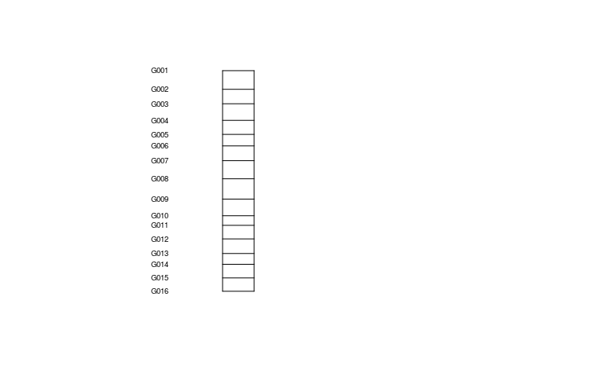

```r
plotChr(maps[[1]], cex = 0.6)
```

We can also compare two chromosome maps:

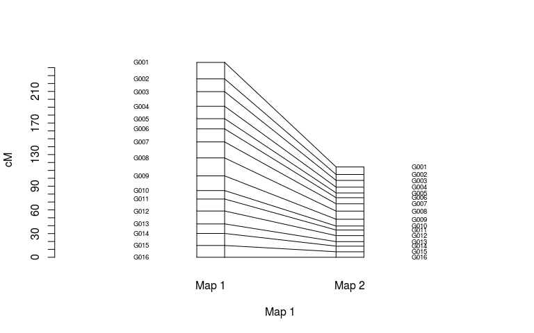

```r
maps2 <- pullMap(rf, split, fun = "kosambi")
plotChr(maps[[1]], maps2[[1]], cex = 0.6)
```

The map based on the Kosambi function is smaller than the default Haldane function.

## Map comparison

To compare two maps on global level we use the package `dendextend`.

```r
library(dendextend)
library(gclus)
```

We create a new map from the existing map `maps2` because otherwise the two dendograms would be equal.

```r
maps3 <- maps2
maps3[1] <- maps2[2]
maps3[2] <- maps2[1]
maps3[3] <- maps2[7]
maps3[[4]] <- rev(max(maps3[[4]]) - maps3[[4]])
maps3[6] <- maps2[3]
maps3[7] <- maps2[6]
maps3[[4]]
```

```
##         D001         D002         D003         D004         D005
##   0.00000000   9.64156202  19.94105675  28.07661676  37.56385730
##         D006         D007         D008         D009         D010
##  45.44088347  53.44507166  63.41105023  69.69391094  78.88703044
##         D011         D012         D013         D014         D015
##  87.14307262  95.41442872 103.45401933 111.49360993 114.77700998
##         D016         D017         D018         D019         D020
## 120.63702763 127.45870229 137.95504843 147.38740421 156.50348205
```

```r
maps2[[4]]
```

```
##         D020         D019         D018         D017         D016
##   0.00000000   9.11607784  18.54843362  29.04477976  35.86645442
##         D015         D014         D013         D012         D011
##  41.72647207  45.00987212  53.04946272  61.08905333  69.36040944
##         D010         D009         D008         D007         D006
##  77.61645161  86.80957111  93.09243182 103.05841039 111.06259858
##         D005         D004         D003         D002         D001
## 118.93962475 128.42686529 136.56242530 146.86192003 156.50348205
```

We create dendogram objects from our previously created maps.

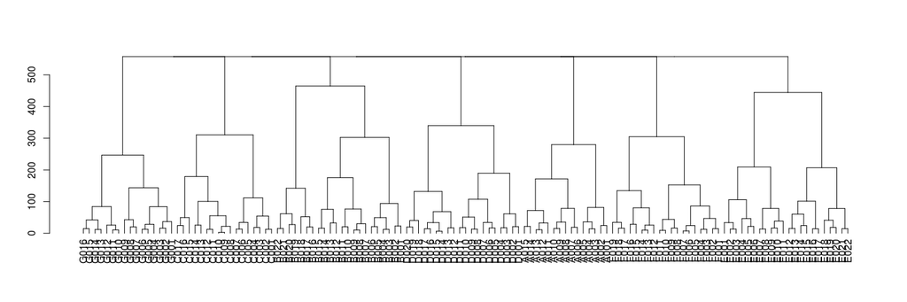

```r
dend1 <- mapToDend(maps)
plot(dend1, cex = 0.6)
```

One is plotted to show what it looks like.

```r
dend2 <- mapToDend(maps3)
```

`maketangle` creates a tanglegram.

```r
makeTangle(dend1, dend2, cutheight = 500, k = 7)
```

[figure not shown]

We can easily observe the rearrangements that we did before. In a real data example we would not want these. We use `switchChrs` and `swapChrs` to reverse them. One map serves as model while the other one is changed.

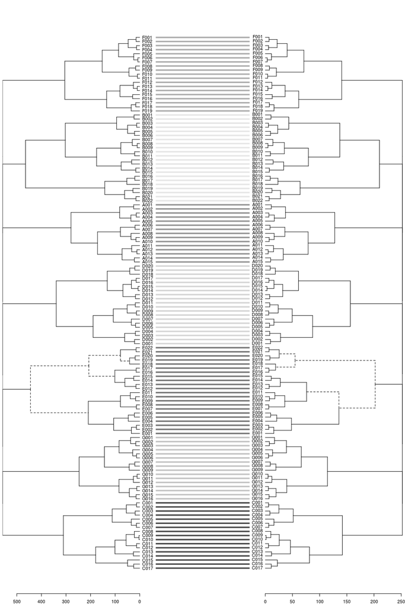

```r
maps <- switchChrs(map = maps, comp = maps3)
maps <- swapChrs(map = maps, comp = maps3)
dend3 <- mapToDend(maps)
dend4 <- mapToDend(maps3)
makeTangle(dend3, dend4, cutheight = 500, k = 7)
```

# Acknowledgement

I thank Jeroen Lodewijk for testing the package and providing valuable feedback about its usablity and this vignette.

# Funding

This work was supported by the European Union’s Seventh Framework Programme for research, technological development and demonstration under grant agreement No. 289974. [INTERCROSSING](http://intercrossing.wikispaces.com/)